# IODS course project

# Week 6. Analysis of longitudinal data

```r
date()
```

```
## [1] "Sun Dec 11 13:15:40 2022"
```

```r
# Packages
library(tidyverse); library(ggplot2); library(dplyr); library(tidyr); library(lme4); library(patchwork)
```

### 1. PART 1 using RATS data

The data used in the exercise comes from a nutrition study conducted in three groups of rats (16 rats in total). These rats were put on different diets and their weights were recorded repeatedly over a 9-week period.

```r
# Read data:
RATSL <- read_csv("data/RATSL.csv")
# Take a look
glimpse(RATSL)
```

```
## Rows: 176
## Columns: 5
## $ id     <dbl> 1, 2, 3, 4, 5, 6, 7, 8, 9, 10, 11, 12, 13, 14, 15, 16, 1, 2, 3,…
## $ group  <dbl> 1, 1, 1, 1, 1, 1, 1, 1, 2, 2, 2, 2, 3, 3, 3, 3, 1, 1, 1, 1, 1, …
## $ WD     <chr> "WD1", "WD1", "WD1", "WD1", "WD1", "WD1", "WD1", "WD1", "WD1", …
## $ weight <dbl> 240, 225, 245, 260, 255, 260, 275, 245, 410, 405, 445, 555, 470…
## $ time   <dbl> 1, 1, 1, 1, 1, 1, 1, 1, 1, 1, 1, 1, 1, 1, 1, 1, 8, 8, 8, 8, 8, …
```

```r
head(RATSL)
```

```
## # A tibble: 6 × 5
##      id group WD    weight  time
##   <dbl> <dbl> <chr>  <dbl> <dbl>
## 1     1     1 WD1      240     1
## 2     2     1 WD1      225     1
## 3     3     1 WD1      245     1
## 4     4     1 WD1      260     1
## 5     5     1 WD1      255     1
## 6     6     1 WD1      260     1
```

```r
names(RATSL)
```

```
## [1] "id"     "group"  "WD"     "weight" "time"
```

```r
# Factor variables id and group
RATSL$id <- factor(RATSL$id)
RATSL$group <- factor(RATSL$group)
```

Plot the weights for each rat, differentiating between treatment groups.

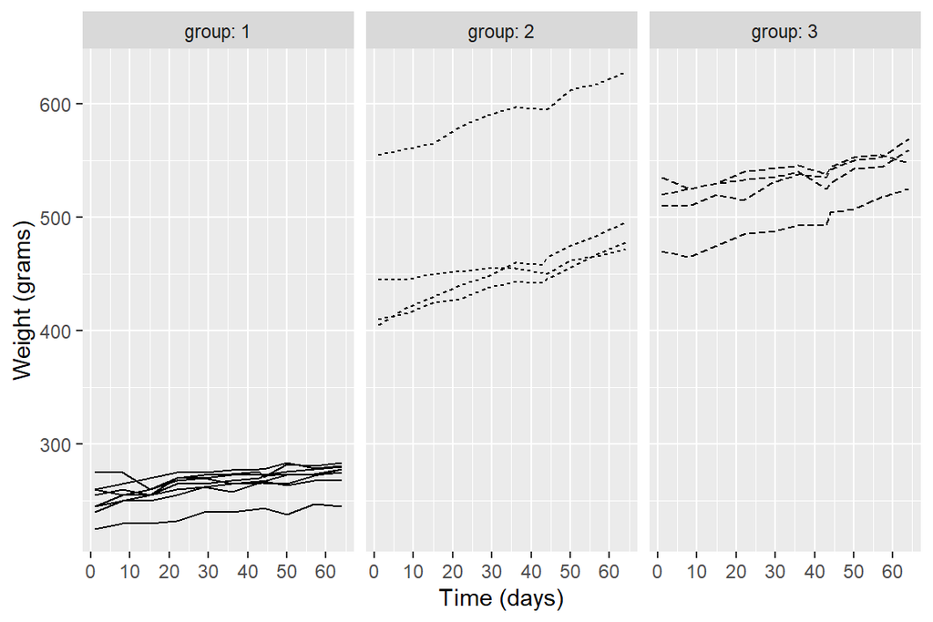

```r
# Draw the plot
ggplot(RATSL, aes(x = time, y = weight, group = id)) +
  geom_line(aes(linetype = group)) +
  facet_grid(. ~ group, labeller = label_both) +
  theme(legend.position = "none") +
#  scale_y_continuous(limits = c(min(RATSL$weight), max(RATSL$weight))) +
  scale_x_continuous(name = "Time (days)", breaks = seq(0, 60, 10))+
  scale_y_continuous(name = "Weight (grams)")
```

Levels of weight differ but the weight gain trajectories seem quite similar across the three groups. What differs is the starting weight. Especially rats in group 1 are much lighter compared to rats in groups 2 and 3.

Standardize weight and draw the plot again.

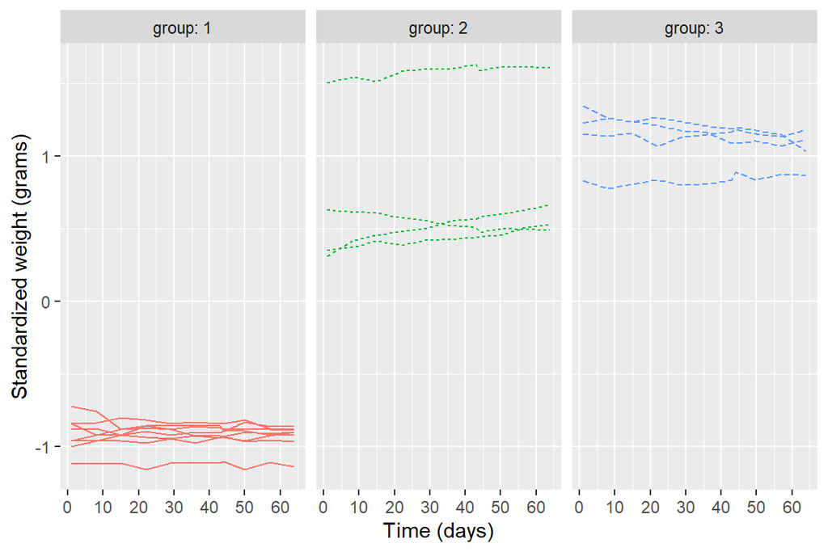

```r
# Standarize
RATSL <- RATSL %>%
  group_by(time) %>%
  mutate(stdweight = (weight - mean(weight)) / sd(weight)) %>%
  ungroup()

# Plot
ggplot(RATSL, aes(x = time, y = stdweight, group = id, color = group)) +
  geom_line(aes(linetype = group)) +
  facet_grid(. ~ group, labeller = label_both) +
  theme(legend.position = "none") +
  scale_x_continuous(name = "Time (days)", breaks = seq(0, 60, 10))+
  scale_y_continuous(name = "Standardized weight (grams)")
```

After standardization weights of rats in group 3 seem to somewhat decline.

Summary graph 1: Mean profiles of weight for each of the three groups, with standard errors.

```r
RATSL <- RATSL %>%
  group_by(group) %>%
  mutate(count = n_distinct(id)) %>%
  ungroup()

# Create a summary data with the mean and standard error of weight
RATSS <- RATSL %>%
  group_by(group, time) %>%
  summarise(mean = mean(weight), se = sd(weight)/sqrt(count) ) %>%
  ungroup()
# Glimpse the data
glimpse(RATSS)
```

```
## Rows: 176
## Columns: 4
## $ group <fct> 1, 1, 1, 1, 1, 1, 1, 1, 1, 1, 1, 1, 1, 1, 1, 1, 1, 1, 1, 1, 1, 1…
## $ time  <dbl> 1, 1, 1, 1, 1, 1, 1, 1, 8, 8, 8, 8, 8, 8, 8, 8, 15, 15, 15, 15, …
## $ mean  <dbl> 250.625, 250.625, 250.625, 250.625, 250.625, 250.625, 250.625, 2…
## $ se    <dbl> 5.381640, 5.381640, 5.381640, 5.381640, 5.381640, 5.381640, 5.38…
```

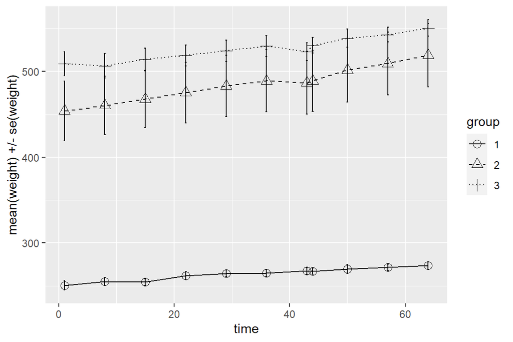

```r
# Plot the mean values by treatment group
ggplot(RATSS, aes(x = time, y = mean, linetype = group, shape = group)) +
  geom_line() +
  scale_linetype_manual(values = c(1,2,3)) +
  geom_point(size=3) +
  scale_shape_manual(values = c(1,2,3)) +
  geom_errorbar(aes(ymin=mean-se, ymax=mean+se, linetype="1"), width=0.3) +
  scale_y_continuous(name = "mean(weight) +/- se(weight)")
```

Summary graph 2 - are there outliers?

```r
# Create a summary dataset by treatment and id with the mean of days 8 to 64 as summary measure (ignoring day 1 baseline)
RATSS2 <- RATSL %>%
  filter(time > 1) %>%
  group_by(group, id) %>%
  summarise(mean=mean(weight) ) %>%
  ungroup()
# Glimpse the data
glimpse(RATSS2)
```

```
## Rows: 16
## Columns: 3
## $ group <fct> 1, 1, 1, 1, 1, 1, 1, 1, 2, 2, 2, 2, 3, 3, 3, 3
## $ id    <fct> 1, 2, 3, 4, 5, 6, 7, 8, 9, 10, 11, 12, 13, 14, 15, 16
## $ mean  <dbl> 263.2, 238.9, 261.7, 267.2, 270.9, 276.2, 274.6, 267.5, 443.9, 4…
```

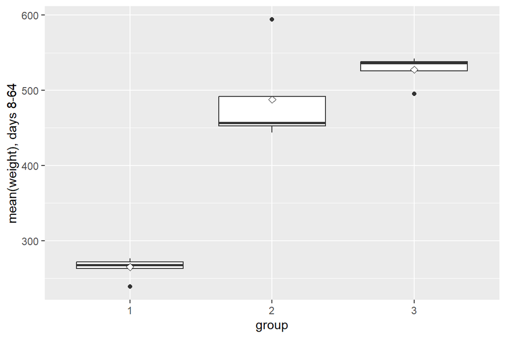

```r
# Box plot of means by treatment group
ggplot(RATSS2, aes(x = group, y = mean)) +
  geom_boxplot() +
  stat_summary(fun = "mean", geom = "point", shape=23, size=2, fill = "white") +
  scale_y_continuous(name = "mean(weight), days 8-64")
```

All three groups seem to have one outlier each. Let’s remove these.

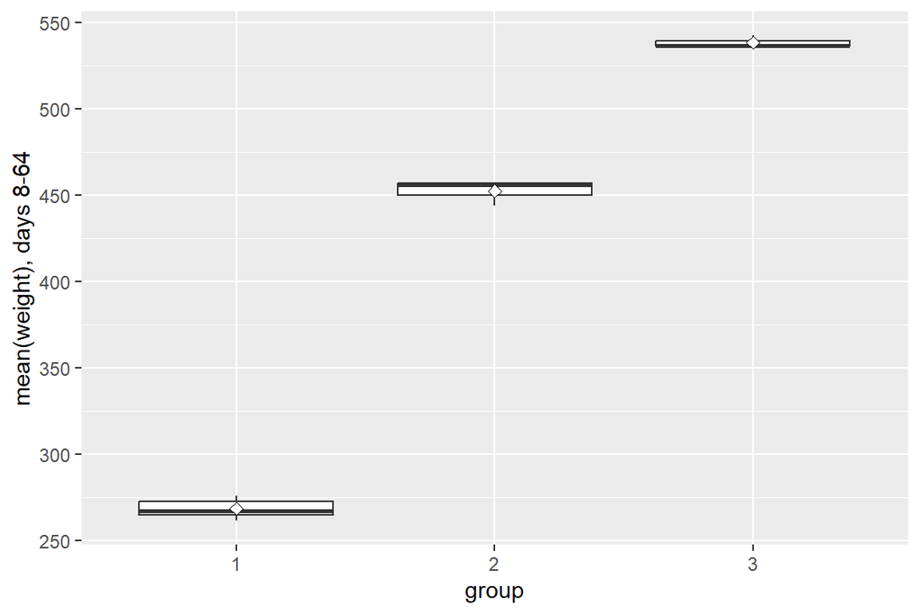

```r
RATSS3 <- RATSS2 %>%
  filter(mean > 250 & group == '1' |
           mean < 550 & group == '2' |
           mean > 500 & group == '3')

# Plot again without outliers
ggplot(RATSS3, aes(x = group, y = mean)) +
  geom_boxplot() +
  stat_summary(fun = "mean", geom = "point", shape=23, size=2, fill = "white") +
  scale_y_continuous(name = "mean(weight), days 8-64")
```

Fit an ANOVA model.

```r
fit = aov(mean ~ group, data = RATSS3)
summary(fit)
```

```
##             Df Sum Sq Mean Sq F value   Pr(>F)
## group        2 176917   88458    2836 1.69e-14 ***
## Residuals   10    312      31
## ---
## Signif. codes:  0 '***' 0.001 '**' 0.01 '*' 0.05 '.' 0.1 ' ' 1
```

The test confirms what the plots have already shown: the mean weights across the three groups are not the same.

Let’s add the baseline from the original data as a new variable to the summary data (now using the data with the outliers) to fit a linear model using the baseline as an additional control.

```r
# Original data in wide format
RATS <- read.table("https://raw.githubusercontent.com/KimmoVehkalahti/MABS/master/Examples/data/rats.txt", sep = "", header = T)

# New column
RATSS4 <- RATSS2 %>%
  mutate(baseline = RATS$WD1)

# Fit a linear model with the mean as the response
fit <- lm(mean ~ baseline + group , data = RATSS4)

# Compute the analysis of variance table for the fitted model with anova()
anova(fit)
```

```
## Analysis of Variance Table
##
## Response: mean
##           Df Sum Sq Mean Sq   F value   Pr(>F)
## baseline   1 253625  253625 1859.8201 1.57e-14 ***
## group      2    879     439    3.2219  0.07586 .
## Residuals 12   1636     136
## ---
## Signif. codes:  0 '***' 0.001 '**' 0.01 '*' 0.05 '.' 0.1 ' ' 1
```

We see that the baseline weight is strongly related to the weight measurements in the following weeks but there is no evidence of a difference between groups even after conditioning on the baseline value.

### 2. PART 2 using BPRS data

The data used in this exercise corresponds to 40 men. These men were randomly assigned to two treatment groups and each of them was rated on a brief psychiatric rating scale (BPRS). Measurements were done before treatment (week 0) and then weekly for eight weeks.

```r
# Read data:
BPRSL <- read_csv("data/BPRSL.csv")
# Take a look
glimpse(BPRSL)
```

```
## Rows: 360
## Columns: 5
## $ treatment <dbl> 1, 1, 1, 1, 1, 1, 1, 1, 1, 1, 1, 1, 1, 1, 1, 1, 1, 1, 1, 1, …
## $ subject   <dbl> 1, 2, 3, 4, 5, 6, 7, 8, 9, 10, 11, 12, 13, 14, 15, 16, 17, 1…
## $ weeks     <chr> "week0", "week0", "week0", "week0", "week0", "week0", "week0…
## $ bprs      <dbl> 42, 58, 54, 55, 72, 48, 71, 30, 41, 57, 30, 55, 36, 38, 66, …
## $ week      <dbl> 0, 0, 0, 0, 0, 0, 0, 0, 0, 0, 0, 0, 0, 0, 0, 0, 0, 0, 0, 0, …
```

```r
head(BPRSL)
```

```
## # A tibble: 6 × 5
##   treatment subject weeks  bprs  week
##       <dbl>   <dbl> <chr> <dbl> <dbl>
## 1         1       1 week0    42     0
## 2         1       2 week0    58     0
## 3         1       3 week0    54     0
## 4         1       4 week0    55     0
## 5         1       5 week0    72     0
## 6         1       6 week0    48     0
```

```r
names(BPRSL)
```

```
## [1] "treatment" "subject"   "weeks"     "bprs"      "week"
```

```r
# Factor variables treatment and subject
BPRSL$treatment <- factor(BPRSL$treatment)
BPRSL$subject <- factor(BPRSL$subject)

str(BPRSL)
```

```
## spc_tbl_ [360 × 5] (S3: spec_tbl_df/tbl_df/tbl/data.frame)
##  $ treatment: Factor w/ 2 levels "1","2": 1 1 1 1 1 1 1 1 1 1 ...
##  $ subject  : Factor w/ 20 levels "1","2","3","4",..: 1 2 3 4 5 6 7 8 9 10 ...
##  $ weeks    : chr [1:360] "week0" "week0" "week0" "week0" ...
##  $ bprs     : num [1:360] 42 58 54 55 72 48 71 30 41 57 ...
##  $ week     : num [1:360] 0 0 0 0 0 0 0 0 0 0 ...
##  - attr(*, "spec")=
##   .. cols(
##   ..   treatment = col_double(),
##   ..   subject = col_double(),
##   ..   weeks = col_character(),
##   ..   bprs = col_double(),
##   ..   week = col_double()
##   .. )
##  - attr(*, "problems")=<externalptr>
```

As a first step lets draw a plot identifying the observations in each treatment group but ignoring the longitudinal nature of the data.

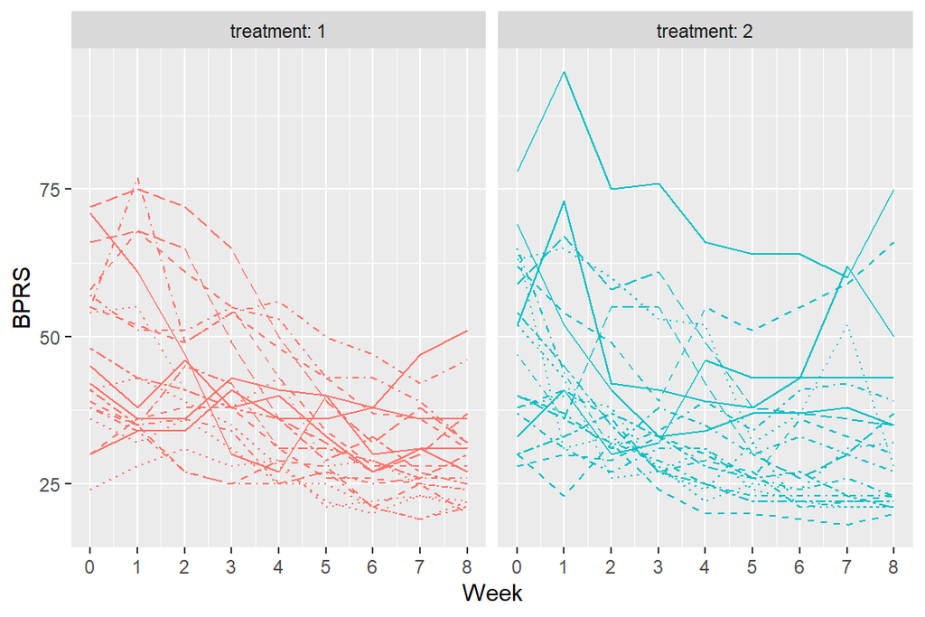

```r
ggplot(BPRSL, aes(x = week, y = bprs, linetype = subject, color = treatment)) +
  geom_line() +
  scale_linetype_manual(values = rep(1:10, times=4)) +
  facet_grid(. ~ treatment, labeller = label_both) +
  theme(legend.position = "none") +
  scale_y_continuous(limits = c(min(BPRSL$bprs), max(BPRSL$bprs)), name = "BPRS") +
  scale_x_continuous(name = "Week", breaks = seq(0, 8, 1))
```

BPRS values show a somewhat declining trend over time but the plot suggests there is little difference between the two treatment groups.

Next a linear model is fitted, still ignoring the repeated-measures structure of the weights in the data.

```r
# Create a regression model BPRS_reg
BPRS_reg <- lm(bprs ~ week + treatment, data = BPRSL)

# print out a summary of the model
summary(BPRS_reg)
```

```
##
## Call:
## lm(formula = bprs ~ week + treatment, data = BPRSL)
##
## Residuals:
##     Min      1Q  Median      3Q     Max
## -22.454  -8.965  -3.196   7.002  50.244
##
## Coefficients:
##             Estimate Std. Error t value Pr(>|t|)
## (Intercept)  46.4539     1.3670  33.982   <2e-16 ***
## week         -2.2704     0.2524  -8.995   <2e-16 ***
## treatment2    0.5722     1.3034   0.439    0.661
## ---
## Signif. codes:  0 '***' 0.001 '**' 0.01 '*' 0.05 '.' 0.1 ' ' 1
##
## Residual standard error: 12.37 on 357 degrees of freedom
## Multiple R-squared:  0.1851, Adjusted R-squared:  0.1806
## F-statistic: 40.55 on 2 and 357 DF,  p-value: < 2.2e-16
```

There seems to be indeed a decreasing trend over the weeks but the model gives no evidence for a significant difference between treatment groups.

Next, a random intercept model is fitted which allows the intercepts of individual men to differ from other men.

```r
# Create a random intercept model
BPRS_ref <- lmer(bprs ~ week + treatment + (1 | subject), data = BPRSL, REML = FALSE)

# Print the summary of the model
summary(BPRS_ref)
```

```
## Linear mixed model fit by maximum likelihood  ['lmerMod']
## Formula: bprs ~ week + treatment + (1 | subject)
##    Data: BPRSL
##
##      AIC      BIC   logLik deviance df.resid
##   2748.7   2768.1  -1369.4   2738.7      355
##
## Scaled residuals:
##     Min      1Q  Median      3Q     Max
## -3.0481 -0.6749 -0.1361  0.4813  3.4855
##
## Random effects:
##  Groups   Name        Variance Std.Dev.
##  subject  (Intercept)  47.41    6.885
##  Residual             104.21   10.208
## Number of obs: 360, groups:  subject, 20
##
## Fixed effects:
##             Estimate Std. Error t value
## (Intercept)  46.4539     1.9090  24.334
## week         -2.2704     0.2084 -10.896
## treatment2    0.5722     1.0761   0.532
##
## Correlation of Fixed Effects:
##            (Intr) week
## week       -0.437
## treatment2 -0.282  0.000
```

Now let’s try letting also the slopes differ, with a random intercept and random slope model.

```r
# Create a random intercept and random slope model
BPRS_ref1 <- lmer(bprs ~ week + treatment + (week | subject), data = BPRSL, REML = FALSE)

# Print a summary of the model
summary(BPRS_ref1)
```

```
## Linear mixed model fit by maximum likelihood  ['lmerMod']
## Formula: bprs ~ week + treatment + (week | subject)
##    Data: BPRSL
##
##      AIC      BIC   logLik deviance df.resid
##   2745.4   2772.6  -1365.7   2731.4      353
##
## Scaled residuals:
##     Min      1Q  Median      3Q     Max
## -2.8919 -0.6194 -0.0691  0.5531  3.7976
##
## Random effects:
##  Groups   Name        Variance Std.Dev. Corr
##  subject  (Intercept) 64.8222  8.0512
##           week         0.9609  0.9802   -0.51
##  Residual             97.4305  9.8707
## Number of obs: 360, groups:  subject, 20
##
## Fixed effects:
##             Estimate Std. Error t value
## (Intercept)  46.4539     2.1052  22.066
## week         -2.2704     0.2977  -7.626
## treatment2    0.5722     1.0405   0.550
##
## Correlation of Fixed Effects:
##            (Intr) week
## week       -0.582
## treatment2 -0.247  0.000
```

Week remains significant but no difference appears between the two treatment groups.

Compare the two previous models:

```r
anova(BPRS_ref1, BPRS_ref)
```

```
## Data: BPRSL
## Models:
## BPRS_ref: bprs ~ week + treatment + (1 | subject)
## BPRS_ref1: bprs ~ week + treatment + (week | subject)
##           npar    AIC    BIC  logLik deviance  Chisq Df Pr(>Chisq)
## BPRS_ref     5 2748.7 2768.1 -1369.4   2738.7
## BPRS_ref1    7 2745.4 2772.6 -1365.7   2731.4 7.2721  2    0.02636 *
## ---
## Signif. codes:  0 '***' 0.001 '**' 0.01 '*' 0.05 '.' 0.1 ' ' 1
```

Random slopes and intercept model performs slightly better. Let’s add an interaction between week and treatment group.

```r
BPRS_ref2 <- lmer(bprs ~ week * treatment + (week | subject), data = BPRSL, REML = FALSE)

# Print a summary of the model
summary(BPRS_ref2)
```

```
## Linear mixed model fit by maximum likelihood  ['lmerMod']
## Formula: bprs ~ week * treatment + (week | subject)
##    Data: BPRSL
##
##      AIC      BIC   logLik deviance df.resid
##   2744.3   2775.4  -1364.1   2728.3      352
##
## Scaled residuals:
##     Min      1Q  Median      3Q     Max
## -3.0512 -0.6271 -0.0768  0.5288  3.9260
##
## Random effects:
##  Groups   Name        Variance Std.Dev. Corr
##  subject  (Intercept) 64.9964  8.0620
##           week         0.9687  0.9842   -0.51
##  Residual             96.4707  9.8220
## Number of obs: 360, groups:  subject, 20
##
## Fixed effects:
##                 Estimate Std. Error t value
## (Intercept)      47.8856     2.2521  21.262
## week             -2.6283     0.3589  -7.323
## treatment2       -2.2911     1.9090  -1.200
## week:treatment2   0.7158     0.4010   1.785
##
## Correlation of Fixed Effects:
##             (Intr) week   trtmn2
## week        -0.650
## treatment2  -0.424  0.469
## wek:trtmnt2  0.356 -0.559 -0.840
```

```r
# perform an ANOVA test on the two models
anova(BPRS_ref2, BPRS_ref1)
```

```
## Data: BPRSL
## Models:
## BPRS_ref1: bprs ~ week + treatment + (week | subject)
## BPRS_ref2: bprs ~ week * treatment + (week | subject)
##           npar    AIC    BIC  logLik deviance  Chisq Df Pr(>Chisq)
## BPRS_ref1    7 2745.4 2772.6 -1365.7   2731.4
## BPRS_ref2    8 2744.3 2775.4 -1364.1   2728.3 3.1712  1    0.07495 .
## ---
## Signif. codes:  0 '***' 0.001 '**' 0.01 '*' 0.05 '.' 0.1 ' ' 1
```

The interaction is not significant and the ANOVA test suggests to stay with the previous ref1 model. I use that for plotting.

```r
# Plot the observed values
p1 <- ggplot(BPRSL, aes(x = week, y = bprs, linetype = subject, color = treatment)) +
  geom_line() +
  scale_linetype_manual(values = rep(1:10, times=4)) +
  facet_grid(. ~ treatment, labeller = label_both) +
  theme(legend.position = "none") +
  scale_y_continuous(limits = c(min(BPRSL$bprs), max(BPRSL$bprs)), name = "Observed bprs") +
  scale_x_continuous(name = "Week", breaks = seq(0, 8, 1))

# Create a vector of the fitted values
fitted <- fitted(BPRS_ref1)

# Add a new column with fitted values BPRSL
BPRSL <-  BPRSL %>%
  mutate(fitted = fitted)
head(BPRSL)
```

```
## # A tibble: 6 × 6
##   treatment subject weeks  bprs  week fitted
##   <fct>     <fct>   <chr> <dbl> <dbl>  <dbl>
## 1 1         1       week0    42     0   47.8
## 2 1         2       week0    58     0   45.5
## 3 1         3       week0    54     0   46.2
## 4 1         4       week0    55     0   48.4
## 5 1         5       week0    72     0   64.9
## 6 1         6       week0    48     0   41.2
```

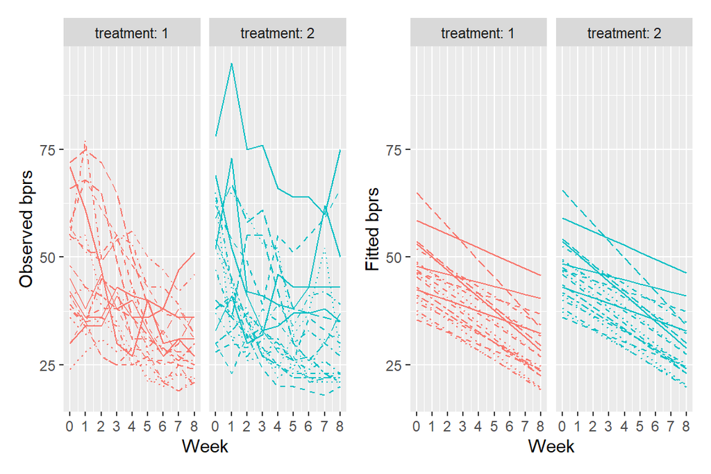

```r
# Plot the fitted values of bprs
p2 <- ggplot(BPRSL, aes(x = week, y = fitted, linetype = subject, color = treatment)) +
  geom_line() +
  scale_linetype_manual(values = rep(1:10, times=4)) +
  facet_grid(. ~ treatment, labeller = label_both) +
  theme(legend.position = "none") +
  scale_y_continuous(limits = c(min(BPRSL$bprs), max(BPRSL$bprs)), name = "Fitted bprs") +
  scale_x_continuous(name = "Week", breaks = seq(0, 8, 1))

p1 | p2
```

Treatment groups seem very alike.